# DEFUNCIONES NO FETALES EN COLOMBIA 2019

Paula Ayala - Luis Hernández - Jhon Panqueva

2026-11-21

# 1. Introducción

Las Estadísticas Vitales del DANE guardan la información de los certificados de defunción de Colombia: sexo y edad de la persona que murió, lugar y mes de la defunción y la probable manera de muerte (enfermedad, homicidio, accidente, etc.).

## Planteamiento del problema

No todas las personas mueren igual ni en los mismos lugares. Las muertes por enfermedad pasan sobre todo en edades avanzadas, mientras que los homicidios y los accidentes afectan a gente más joven y se concentran en algunas ciudades. Si no se describen estos patrones, es difícil saber qué grupos y qué territorios tienen más defunciones.

**Pregunta:** ¿Cómo fueron las defunciones no fetales en Colombia en 2019 según la edad, el sexo y la manera de muerte, y qué departamentos y municipios tuvieron más defunciones?

## Objetivo general

Describir con análisis exploratorio de datos las defunciones no fetales de Colombia en 2019 según edad, sexo, manera de muerte y lugar de ocurrencia.

## Objetivos específicos

1. Limpiar la base de datos (datos perdidos, códigos de “sin información” y datos duplicados).
2. Calcular las medidas descriptivas de la edad al fallecer y graficarla (histograma y boxplot).
3. Ver cómo se distribuyen las defunciones según manera de muerte, sexo y mes.
4. Encontrar los 10 departamentos y los 10 municipios con más defunciones, y los 10 municipios con más homicidios.

# 2. Descripción de los datos

Los datos son de la plataforma Microdatos del DANE: **Estadísticas Vitales 2019, archivo `nofetal2019`** (defunciones no fetales).

Enlace: https://microdatos.dane.gov.co/index.php/catalog/696

Cada fila es una defunción. El archivo tiene 56 variables, pero para este trabajo usamos solo 6. En la tabla están con el ID y la etiqueta que aparecen en el diccionario de datos (PDF):

```r
variables <- data.frame(
  ID_PDF = c("V1338", "V1339", "V1345", "V1348", "V1350", "V1363"),
  Variable = c("COD_DPTO", "COD_MUNIC", "MES", "SEXO", "GRU_ED1", "P_PMAN_IRIS"),
  Etiqueta_PDF = c("Departamento donde ocurrió la defunción",
                   "Municipio donde ocurrió la defunción",
                   "Mes en que ocurrió la defunción",
                   "Sexo del fallecido",
                   "Agrupación de edades, según la edad del fallecido",
                   "Probable manera de muerte"),
  Tipo = c("Código departamento", "Código municipio", "Cuantitativa discreta",
           "Cualitativa", "CUANTITATIVA (edad agrupada)", "CUALITATIVA"),
  Uso = c("Top 10 departamentos", "Top 10 municipios", "Defunciones por mes",
          "Cruce con otras variables", "Variable cuantitativa", "Variable cualitativa")
)
variables
```

```
##   ID_PDF    Variable                                      Etiqueta_PDF
## 1  V1338    COD_DPTO           Departamento donde ocurrió la defunción
## 2  V1339   COD_MUNIC              Municipio donde ocurrió la defunción
## 3  V1345         MES                   Mes en que ocurrió la defunción
## 4  V1348        SEXO                                Sexo del fallecido
## 5  V1350     GRU_ED1 Agrupación de edades, según la edad del fallecido
## 6  V1363 P_PMAN_IRIS                         Probable manera de muerte
##                           Tipo                       Uso
## 1          Código departamento      Top 10 departamentos
## 2             Código municipio         Top 10 municipios
## 3        Cuantitativa discreta       Defunciones por mes
## 4                  Cualitativa Cruce con otras variables
## 5 CUANTITATIVA (edad agrupada)     Variable cuantitativa
## 6                  CUALITATIVA      Variable cualitativa
```

También usamos `TIPO_DEFUN` (V1343) y `ANO` (V1344) solo para revisar que todo sea defunción no fetal de 2019.

# 3. Carga de los datos

```r
# Busco la carpeta donde están los datos
ruta <- c("D:\\ESPECIALIZACIÓN\\ACT1 - Ciencia de datos\\ACT1 - Ciencia de datos\\ACT1 - Ciencia de datos\\DATOS")
ruta <- ruta[dir.exists(ruta)][1]
list.files(ruta) # Visualizo archivos de la carpeta
```

```
## [1] "nofetal2019.csv"
```

En esta línea cargamos la matriz de datos. Se lee todo como texto para no perder los ceros de los códigos (por ejemplo “001”).

```r
data <- read.csv(file.path(ruta, "nofetal2019.csv"), colClasses = "character",
                 fileEncoding = "latin1")
```

## Exploración de los datos

```r
dim(data)
```

```
## [1] 244355     56
```

```r
colnames(data)
```

```
##  [1] "COD_DPTO"       "COD_MUNIC"      "A_DEFUN"        "SIT_DEFUN"
##  [5] "OTRSITIODE"     "TIPO_DEFUN"     "ANO"            "MES"
##  [9] "HORA"           "MINUTOS"        "SEXO"           "EST_CIVIL"
## [13] "GRU_ED1"        "GRU_ED2"        "NIVEL_EDU"      "ULTCURFAL"
## [17] "MUERTEPORO"     "SIMUERTEPO"     "OCUPACION"      "IDPERTET"
## [21] "CODPRES"        "CODPTORE"       "CODMUNRE"       "AREA_RES"
## [25] "SEG_SOCIAL"     "IDADMISALUD"    "P_PMAN_IRIS"    "CONS_EXP"
## [29] "MU_PARTO"       "T_PARTO"        "TIPO_EMB"       "T_GES"
## [33] "T_GES_AGRU_CIE" "PESO_NAC"       "EDAD_MADRE"     "N_HIJOSV"
## [37] "N_HIJOSM"       "EST_CIVM"       "NIV_EDUM"       "ULTCURMAD"
## [41] "EMB_FAL"        "EMB_SEM"        "EMB_MES"        "CODOCUR"
## [45] "CODMUNOC"       "C_MUERTE"       "C_MUERTEB"      "C_MUERTEC"
## [49] "C_MUERTED"      "C_MUERTEE"      "ASIS_MED"       "CAUSA_MULT"
## [53] "C_BAS1"         "CAUSA_667"      "IDPROFCER"      "CAU_HOMOL"
```

```r
head(data[, 1:12])
```

```
##   COD_DPTO COD_MUNIC A_DEFUN SIT_DEFUN OTRSITIODE TIPO_DEFUN  ANO MES HORA
## 1       66       682       1         5                     2 2019  11   23
## 2       17       001       1         1                     2 2019  12   21
## 3       25       843       1         1                     2 2019  12   20
## 4       23       001       1         1                     2 2019  12   14
## 5       73       001       1         1                     2 2019  11   08
## 6       19       001       1         3                     2 2019  12   05
##   MINUTOS SEXO EST_CIVIL
## 1      00    2         5
## 2      10    1         6
## 3      15    2         4
## 4      20    2         1
## 5      40    2         4
## 6      00    2         5
```

Revisamos que todo sea defunción no fetal (TIPO_DEFUN = 2) del año 2019:

```r
table(data$TIPO_DEFUN)
```

```
##
##      2
## 244355
```

```r
table(data$ANO)
```

```
##
##   2019
## 244355
```

# 4. Selección de variables

```r
vars <- c("COD_DPTO", "COD_MUNIC", "MES", "SEXO", "GRU_ED1", "P_PMAN_IRIS")
data_sel <- data[, vars]

# Pasamos los códigos a número
data_sel[] <- lapply(data_sel, as.integer)
str(data_sel)
```

```
## 'data.frame':    244355 obs. of  6 variables:
##  $ COD_DPTO   : int  66 17 25 23 73 19 25 25 5 73 ...
##  $ COD_MUNIC  : int  682 1 843 1 1 1 175 335 45 168 ...
##  $ MES        : int  11 12 12 12 11 12 11 11 11 12 ...
##  $ SEXO       : int  2 1 2 2 2 2 1 1 1 1 ...
##  $ GRU_ED1    : int  15 16 19 23 23 20 11 12 12 20 ...
##  $ P_PMAN_IRIS: int  1 0 5 0 0 0 1 4 2 0 ...
```

Con el código del departamento y el del municipio armamos el código del municipio de 5 números.

```r
data_sel$COD_MPIO <- data_sel$COD_DPTO * 1000 + data_sel$COD_MUNIC
head(data_sel)
```

```
##   COD_DPTO COD_MUNIC MES SEXO GRU_ED1 P_PMAN_IRIS COD_MPIO
## 1       66       682  11    2      15           1    66682
## 2       17         1  12    1      16           0    17001
## 3       25       843  12    2      19           5    25843
## 4       23         1  12    2      23           0    23001
## 5       73         1  11    2      23           0    73001
## 6       19         1  12    2      20           0    19001
```

## Categorías según el PDF

Antes de limpiar miramos cuántos registros hay en cada código del diccionario.

**SEXO:** 1 = Masculino, 2 = Femenino, 3 = Indeterminado

```r
table(data_sel$SEXO)
```

```
##
##      1      2      3
## 134573 109689     93
```

**P_PMAN_IRIS:** 0 = Natural (enfermedad), 1 = Homicidio, 2 = Accidente, 3 = Pendiente de investigación, 4 = Suicidio, 5 = No se pudo determinar, 6 = Desconocido, 8 = Intervención legal, 9 = Guerra

```r
table(data_sel$P_PMAN_IRIS)
```

```
##
##      0      1      2      3      4      5
## 212703  13077  12332    978   2930   2335
```

**GRU_ED1:** 00 = Menor de una hora, 01 = Menor de un día, 02 = De 1 a 6 días, 03 = De 7 a 27 días, 04 = De 28 a 29 días, 05 = De 1 a 5 meses, 06 = De 6 a 11 meses, 07 = De 1 año, 08 = De 2 a 4 años, 09 = De 5 a 9 años, 10 = De 10 a 14 años, …, 27 = De 95 a 99 años, 28 = De 100 años y más, 29 = Edad desconocida

```r
table(data_sel$GRU_ED1)
```

```
##
##     0     1     2     3     4     5     6     7     8     9    10    11    12
##   313   971  1743  1425    68  1847   924   747   771   854  1139  3795  5911
##    13    14    15    16    17    18    19    20    21    22    23    24    25
##  5929  5641  5675  5960  6930  9463 12712 16553 19793 22632 26404 30071 27955
##    26    27    28    29
## 18743  7518  1845    23
```

**MES:** 01 = Enero, …, 12 = Diciembre

```r
table(data_sel$MES)
```

```
##
##     1     2     3     4     5     6     7     8     9    10    11    12
## 21354 17974 19952 19233 20292 20742 21372 21160 19778 20490 20330 21678
```

# 5. Limpieza de datos

## Valores faltantes

```r
# Número total de datos perdidos
total_na <- sum(is.na(data_sel))
print(paste("Total de datos perdidos:", total_na))
```

```
## [1] "Total de datos perdidos: 0"
```

```r
# Número de datos perdidos por columna
na_por_columna <- colSums(is.na(data_sel))

tabla_na <- data.frame(
  Columna = names(na_por_columna),
  Datos_Perdidos = na_por_columna
)

tabla_na_ordenada <- tabla_na %>%
  arrange(desc(Datos_Perdidos)) %>%
  rbind(data.frame(Columna = "Total", Datos_Perdidos = total_na))
tabla_na_ordenada
```

```
##                 Columna Datos_Perdidos
## COD_DPTO       COD_DPTO              0
## COD_MUNIC     COD_MUNIC              0
## MES                 MES              0
## SEXO               SEXO              0
## GRU_ED1         GRU_ED1              0
## P_PMAN_IRIS P_PMAN_IRIS              0
## COD_MPIO       COD_MPIO              0
## 1                 Total              0
```

No hay datos perdidos como `NA`, pero en las bases del DANE los datos desconocidos vienen con un código especial. Según el PDF:

- GRU_ED1 = 29 es “Edad desconocida”
- P_PMAN_IRIS = 6 es “Desconocido (no completado)”

```r
sum(data_sel$GRU_ED1 == 29)
```

```
## [1] 23
```

```r
sum(data_sel$P_PMAN_IRIS == 6)
```

```
## [1] 0
```

Esos códigos los convertimos en `NA`, porque si no R los tomaría como edades o maneras de muerte reales. SEXO = 3 (Indeterminado) sí se deja porque es una categoría válida.

```r
data_sel$GRU_ED1[data_sel$GRU_ED1 == 29] <- NA
data_sel$P_PMAN_IRIS[data_sel$P_PMAN_IRIS == 6] <- NA

colSums(is.na(data_sel))
```

```
##    COD_DPTO   COD_MUNIC         MES        SEXO     GRU_ED1 P_PMAN_IRIS
##           0           0           0           0          23           0
##    COD_MPIO
##           0
```

## TOTAL DATOS DUPLICADOS

Esta base no tiene un número que identifique cada defunción. Por eso los duplicados se buscan en **todas las columnas originales** (las 56) y no solo en las 6 que escogimos.

```r
sum(duplicated(data))
```

```
## [1] 18
```

Identificamos los datos duplicados:

```r
data[duplicated(data), 1:12]
```

```
##        COD_DPTO COD_MUNIC A_DEFUN SIT_DEFUN            OTRSITIODE TIPO_DEFUN
## 11404        52       203       3         6 INSTITUCION EDUCATIVA          2
## 14806        05       001       1         3                                2
## 31021        20       001       3         3                                2
## 32007        20       001       3         3                                2
## 36800        27       006       3         6                   MAR          2
## 51400        11       001       1         3                                2
## 53677        76       834       1         5                                2
## 54044        76       520       1         3                                2
## 151080       27       006       3         6                   MAR          2
## 153701       05       001       1         3                                2
## 187410       05       847       1         1                                2
## 199172       52       036       3         5                                2
## 199753       76       001       1         5                                2
## 202784       27       006       3         6                   MAR          2
```

[output cut: 23 more lines]

Si buscáramos duplicados solo con nuestras 6 variables saldrían muchísimas filas:

```r
sum(duplicated(data_sel[, vars]))
```

```
## [1] 162575
```

Esas filas **no** son datos repetidos: son personas distintas que coinciden en departamento, municipio, mes, sexo, edad y manera de muerte. Si las borramos, estaríamos eliminando defunciones reales. Por eso solo eliminamos las 18 filas que son iguales en todas las columnas.

Eliminamos datos duplicados:

```r
data_sin <- data_sel[!duplicated(data), ]
dim(data_sin)
```

```
## [1] 244337      7
```

## COMO SE ELIMINAN DATOS PERDIDOS

Los datos perdidos son muy pocos y no tiene sentido imputar la edad o la manera de muerte de alguien que murió (sería inventar el dato). Entonces los eliminamos con `na.omit()`.

```r
data_limpia <- na.omit(data_sin)
dim(data_limpia)
```

```
## [1] 244315      7
```

```r
print(paste("Filas eliminadas por datos perdidos:", nrow(data_sin) - nrow(data_limpia)))
```

```
## [1] "Filas eliminadas por datos perdidos: 22"
```

## PONER NOMBRES A LOS CÓDIGOS

Cambiamos los códigos por las etiquetas del PDF.

```r
# Sexo
data_limpia$Sexo <- factor(data_limpia$SEXO, levels = c(1, 2, 3),
                           labels = c("Masculino", "Femenino", "Indeterminado"))

# Manera de muerte
data_limpia$Manera_Muerte <- factor(data_limpia$P_PMAN_IRIS,
  levels = c(0, 1, 2, 3, 4, 5, 8, 9),
  labels = c("Natural (enfermedad)", "Homicidio", "Accidente",
             "Pendiente de investigacion", "Suicidio", "No se pudo determinar",
             "Intervencion legal", "Guerra"))

# Mes
data_limpia$Mes <- factor(data_limpia$MES, levels = 1:12,
  labels = c("Ene", "Feb", "Mar", "Abr", "May", "Jun",
             "Jul", "Ago", "Sep", "Oct", "Nov", "Dic"))

# Departamento
departamentos <- c("5" = "Antioquia", "8" = "Atlantico", "11" = "Bogota D.C.",
  "13" = "Bolivar", "15" = "Boyaca", "17" = "Caldas", "18" = "Caqueta",
  "19" = "Cauca", "20" = "Cesar", "23" = "Cordoba", "25" = "Cundinamarca",
  "27" = "Choco", "41" = "Huila", "44" = "La Guajira", "47" = "Magdalena",
  "50" = "Meta", "52" = "Narino", "54" = "Norte de Santander", "63" = "Quindio",
  "66" = "Risaralda", "68" = "Santander", "70" = "Sucre", "73" = "Tolima",
  "76" = "Valle del Cauca", "81" = "Arauca", "85" = "Casanare", "86" = "Putumayo",
  "88" = "San Andres y Providencia", "91" = "Amazonas", "94" = "Guainia",
  "95" = "Guaviare", "97" = "Vaupes", "99" = "Vichada")
data_limpia$Departamento <- unname(departamentos[as.character(data_limpia$COD_DPTO)])

# Municipio (la base solo trae el código, así que le ponemos nombre a las ciudades principales)
municipios <- c("5001" = "Medellin", "5088" = "Bello", "5360" = "Itagui",
  "8001" = "Barranquilla", "8758" = "Soledad", "11001" = "Bogota D.C.",
  "13001" = "Cartagena", "15001" = "Tunja", "17001" = "Manizales",
  "20001" = "Valledupar", "23001" = "Monteria", "25754" = "Soacha",
  "41001" = "Neiva", "47001" = "Santa Marta", "50001" = "Villavicencio",
  "52001" = "Pasto", "52835" = "Tumaco", "54001" = "Cucuta", "63001" = "Armenia",
  "66001" = "Pereira", "68001" = "Bucaramanga", "68276" = "Floridablanca",
  "70001" = "Sincelejo", "73001" = "Ibague", "76001" = "Cali",
  "76109" = "Buenaventura", "76520" = "Palmira", "76834" = "Tulua")
data_limpia$Municipio <- unname(municipios[as.character(data_limpia$COD_MPIO)])
data_limpia$Municipio <- ifelse(is.na(data_limpia$Municipio),
                                paste("Mpio", sprintf("%05d", data_limpia$COD_MPIO)),
                                data_limpia$Municipio)
head(data_limpia)
```

```
##   COD_DPTO COD_MUNIC MES SEXO GRU_ED1 P_PMAN_IRIS COD_MPIO      Sexo
## 1       66       682  11    2      15           1    66682  Femenino
## 2       17         1  12    1      16           0    17001 Masculino
## 3       25       843  12    2      19           5    25843  Femenino
## 4       23         1  12    2      23           0    23001  Femenino
## 5       73         1  11    2      23           0    73001  Femenino
## 6       19         1  12    2      20           0    19001  Femenino
##           Manera_Muerte Mes Departamento  Municipio
## 1             Homicidio Nov    Risaralda Mpio 66682
## 2  Natural (enfermedad) Dic       Caldas  Manizales
## 3 No se pudo determinar Dic Cundinamarca Mpio 25843
## 4  Natural (enfermedad) Dic      Cordoba   Monteria
## 5  Natural (enfermedad) Nov       Tolima     Ibague
## 6  Natural (enfermedad) Dic        Cauca Mpio 19001
```

## EDAD APROXIMADA

La edad viene en grupos (GRU_ED1) y no en años exactos. Para poder sacar la media, la mediana, etc., cambiamos cada grupo por su **punto medio**. Por ejemplo, “De 15 a 19 años” (código 11) pasa a ser 17,5. Los menores de un año (códigos 0 a 6) quedan en 0,5 y “100 años y más” (código 28) en 100.

```r
# Punto medio de cada grupo, de GRU_ED1 = 0 hasta GRU_ED1 = 28
puntos_medios <- c(rep(0.5, 7), 1.5, 3.5, seq(7.5, 97.5, by = 5), 100)

# Se suma 1 porque el código 0 está en la primera posición del vector
data_limpia$Edad <- puntos_medios[data_limpia$GRU_ED1 + 1]

# Revisión: código y su edad aproximada
unique(data_limpia[order(data_limpia$GRU_ED1), c("GRU_ED1", "Edad")])
```

```
##      GRU_ED1  Edad
## 247        0   0.5
## 148        1   0.5
## 73         2   0.5
## 47         3   0.5
## 1801       4   0.5
## 18         5   0.5
## 273        6   0.5
## 120        7   1.5
## 307        8   3.5
## 128        9   7.5
## 16        10  12.5
## 7         11  17.5
## 8         12  22.5
## 56        13  27.5
## 20        14  32.5
## 1         15  37.5
## 2         16  42.5
## 83        17  47.5
## 41        18  52.5
## 3         19  57.5
## 6         20  62.5
## 32        21  67.5
## 15        22  72.5
## 4         23  77.5
## 29        24  82.5
## 12        25  87.5
## 17        26  92.5
## 156       27  97.5
## 261       28 100.0
```

Ojo: la edad es aproximada porque el dato original está agrupado.

# 6. Análisis exploratorio de datos

## ANÁLISIS DE VARIABLES CUALITATIVAS

### Manera de muerte

```r
tabla_manera <- data.frame(sort(table(data_limpia$Manera_Muerte), decreasing = TRUE))
colnames(tabla_manera) <- c("Manera_Muerte", "Frecuencia")
tabla_manera <- tabla_manera[tabla_manera$Frecuencia > 0, ]
tabla_manera$Porcentaje <- round(100 * tabla_manera$Frecuencia / sum(tabla_manera$Frecuencia), 2)
tabla_manera
```

```
##                Manera_Muerte Frecuencia Porcentaje
## 1       Natural (enfermedad)     212698      87.06
## 2                  Homicidio      13067       5.35
## 3                  Accidente      12328       5.05
## 4                   Suicidio       2930       1.20
## 5      No se pudo determinar       2320       0.95
## 6 Pendiente de investigacion        972       0.40
```

De un total de 244.315 defunciones analizadas (*n* = 244315), la manera de muerte que más se repite es **Natural (enfermedad)**, con 212.698 casos (87.06%). En segundo lugar está **Homicidio** con 5.35% y en tercer lugar **Accidente** con 5.05%.

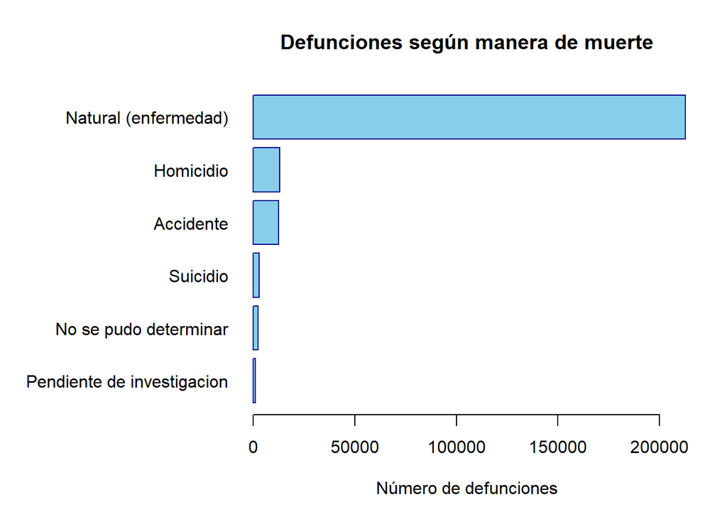

```r
par(mar = c(5, 12, 4, 2))
barplot(rev(tabla_manera$Frecuencia),
        names.arg = rev(tabla_manera$Manera_Muerte),
        horiz = TRUE, las = 1,
        col = "skyblue", border = "darkblue",
        main = "Defunciones según manera de muerte",
        xlab = "Número de defunciones")
```

### Sexo

```r
tabla_sexo <- data.frame(sort(table(data_limpia$Sexo), decreasing = TRUE))
colnames(tabla_sexo) <- c("Sexo", "Frecuencia")
tabla_sexo$Porcentaje <- round(100 * tabla_sexo$Frecuencia / sum(tabla_sexo$Frecuencia), 2)
tabla_sexo
```

```
##            Sexo Frecuencia Porcentaje
## 1     Masculino     134559      55.08
## 2      Femenino     109679      44.89
## 3 Indeterminado         77       0.03
```

El grupo **Masculino** es el más grande, con 134.559 casos (55.08%). El grupo **Femenino** tiene 109.679 casos (44.89%). La categoría Indeterminado tiene muy pocos casos.

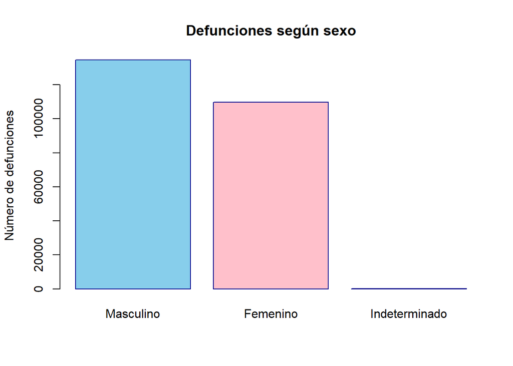

```r
barplot(table(data_limpia$Sexo),
        col = c("skyblue", "pink", "gray"),
        border = "darkblue",
        main = "Defunciones según sexo",
        ylab = "Número de defunciones")
```

### Mes

```r
tabla_mes <- table(data_limpia$Mes)
tabla_mes
```

```
##
##   Ene   Feb   Mar   Abr   May   Jun   Jul   Ago   Sep   Oct   Nov   Dic
## 21347 17972 19949 19231 20287 20740 21370 21158 19777 20487 20325 21672
```

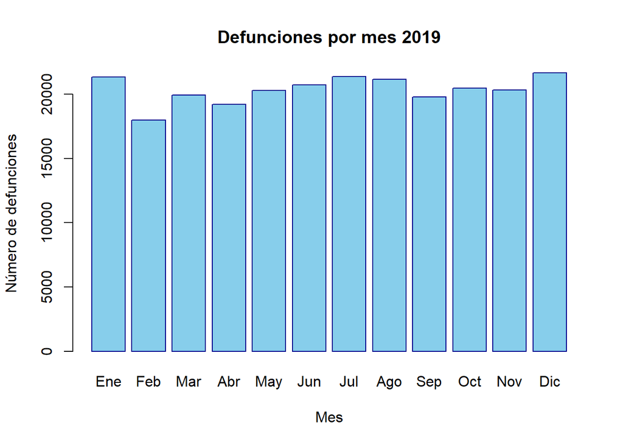

```r
barplot(tabla_mes,
        col = "skyblue", border = "darkblue",
        main = "Defunciones por mes 2019",
        xlab = "Mes", ylab = "Número de defunciones")
```

### Manera de muerte según sexo

```r
tabla_cruce <- table(data_limpia$Manera_Muerte, data_limpia$Sexo)
tabla_cruce <- tabla_cruce[rowSums(tabla_cruce) > 0, c("Masculino", "Femenino")]
tabla_cruce
```

```
##
##                              Masculino Femenino
##   Natural (enfermedad)          108449   104248
##   Homicidio                      11935     1117
##   Accidente                       9532     2795
##   Pendiente de investigacion       641      317
##   Suicidio                        2342      588
##   No se pudo determinar           1660      614
```

```r
# Porcentaje dentro de cada sexo
round(100 * prop.table(tabla_cruce, margin = 2), 2)
```

```
##
##                              Masculino Femenino
##   Natural (enfermedad)           80.60    95.05
##   Homicidio                       8.87     1.02
##   Accidente                       7.08     2.55
##   Pendiente de investigacion      0.48     0.29
##   Suicidio                        1.74     0.54
##   No se pudo determinar           1.23     0.56
```

## ANÁLISIS DE LA VARIABLE CUANTITATIVA: EDAD

```r
summary(data_limpia$Edad)
```

```
##    Min. 1st Qu.  Median    Mean 3rd Qu.    Max.
##    0.50   57.50   72.50   66.44   82.50  100.00
```

```r
# Función para calcular la moda
moda <- function(x) {
  tabla <- table(x)
  as.numeric(names(tabla)[which.max(tabla)])
}

# Calcular estadísticos
estadisticos <- data.frame(
  Estadístico = c("Media", "Mediana", "Moda", "Desviación Estándar", "Mínimo", "Máximo",
                  "Q1 (25%)", "Q2 (50%)", "Q3 (75%)"),
  Valor = c(
    mean(data_limpia$Edad),
    median(data_limpia$Edad),
    moda(data_limpia$Edad),
    sd(data_limpia$Edad),
    min(data_limpia$Edad),
    max(data_limpia$Edad),
    quantile(data_limpia$Edad, probs = 0.25),
    quantile(data_limpia$Edad, probs = 0.50),
    quantile(data_limpia$Edad, probs = 0.75)
  )
)
estadisticos$Valor <- round(estadisticos$Valor, 2)
rownames(estadisticos) <- NULL
estadisticos
```

```
##           Estadístico  Valor
## 1               Media  66.44
## 2             Mediana  72.50
## 3                Moda  82.50
## 4 Desviación Estándar  23.96
## 5              Mínimo   0.50
## 6              Máximo 100.00
## 7            Q1 (25%)  57.50
## 8            Q2 (50%)  72.50
## 9            Q3 (75%)  82.50
```

La edad promedio al fallecer es de 66.4 años, la mediana es de 72.5 años y la moda es de 82.5 años. Como la media es menor que la mediana, hay una cola hacia las edades jóvenes (las muertes de bebés, niños y jóvenes bajan el promedio).

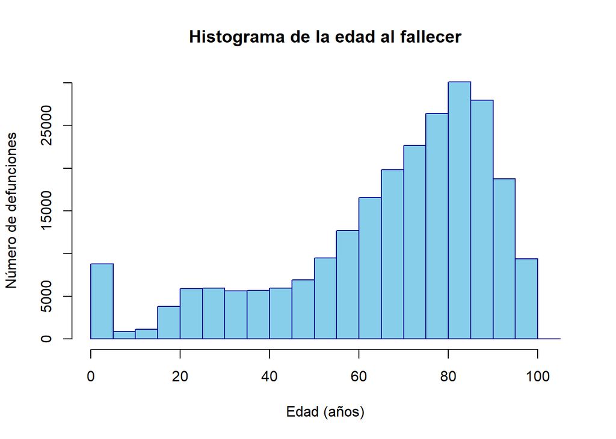

```r
hist(data_limpia$Edad,
     breaks = seq(0, 105, by = 5),
     col = "skyblue",
     border = "darkblue",
     main = "Histograma de la edad al fallecer",
     xlab = "Edad (años)",
     ylab = "Número de defunciones")
```

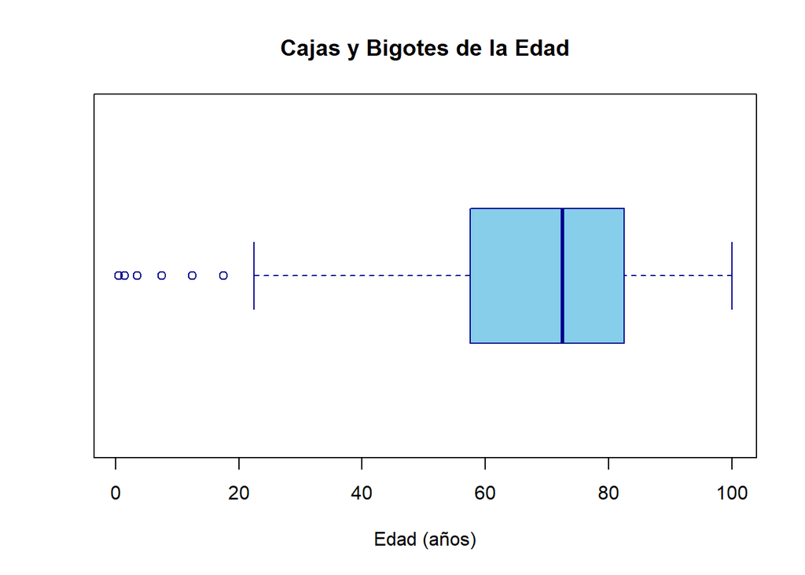

```r
boxplot(
  data_limpia$Edad,
  horizontal = TRUE,
  col = "skyblue",
  border = "darkblue",
  main = "Cajas y Bigotes de la Edad",
  xlab = "Edad (años)")
```

### Edad según sexo

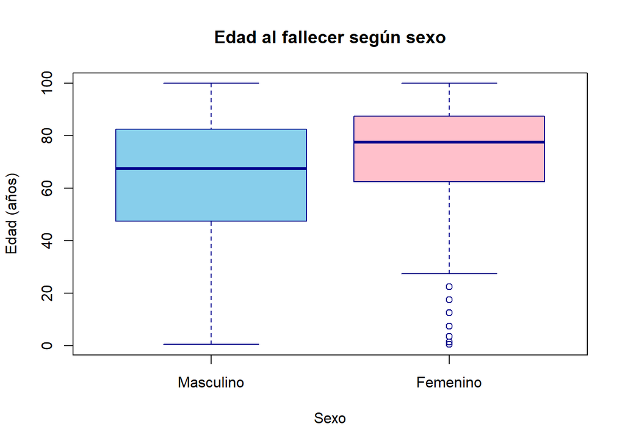

```r
boxplot(Edad ~ Sexo,
        data = droplevels(data_limpia[data_limpia$Sexo != "Indeterminado", ]),
        col = c("skyblue", "pink"),
        border = "darkblue",
        main = "Edad al fallecer según sexo",
        xlab = "Sexo", ylab = "Edad (años)")
```

```r
tapply(data_limpia$Edad, data_limpia$Sexo, median)
```

```
##     Masculino      Femenino Indeterminado
##          67.5          77.5          62.5
```

### Edad según manera de muerte

```r
tapply(data_limpia$Edad, droplevels(data_limpia$Manera_Muerte), median)
```

```
##       Natural (enfermedad)                  Homicidio
##                       77.5                       32.5
##                  Accidente Pendiente de investigacion
##                       42.5                       37.5
##                   Suicidio      No se pudo determinar
##                       32.5                       52.5
```

## IDENTIFICACIÓN DE VALORES ATÍPICOS

Usamos el método del IQR: es atípico lo que esté por debajo de Q1 - 1.5 × IQR o por encima de Q3 + 1.5 × IQR.

```r
# Calcular cuartiles
Q1 <- quantile(data_limpia$Edad, 0.25)
Q3 <- quantile(data_limpia$Edad, 0.75)

# Calcular rango intercuartílico
IQR_valor <- IQR(data_limpia$Edad)

# Definir límites
limite_inferior <- Q1 - 1.5 * IQR_valor
limite_superior <- Q3 + 1.5 * IQR_valor
limite_inferior
```

```
## 25%
##  20
```

```r
limite_superior
```

```
## 75%
## 120
```

```r
# Mostrar valores atípicos
atipicos <- data_limpia[data_limpia$Edad < limite_inferior | data_limpia$Edad > limite_superior, ]
nrow(atipicos)
```

```
## [1] 14594
```

```r
table(atipicos$Edad)
```

```
##
##  0.5  1.5  3.5  7.5 12.5 17.5
## 7291  747  771  852 1138 3795
```

Los atípicos son muertes de bebés, niños y jóvenes (por debajo del límite inferior). **No los eliminamos** porque no son errores: son defunciones reales y quitarlas dañaría el análisis. Además todas las edades están entre 0 y 100 años, o sea que no hay valores imposibles.

## TOP 10 DEPARTAMENTOS Y MUNICIPIOS

Usamos como métrica el **número de defunciones** según el lugar donde ocurrieron.

### Top 10 departamentos con más defunciones

```r
top_dptos <- data.frame(sort(table(data_limpia$Departamento), decreasing = TRUE))
colnames(top_dptos) <- c("Departamento", "Defunciones")
top_dptos$Porcentaje <- round(100 * top_dptos$Defunciones / nrow(data_limpia), 2)
top_dptos <- head(top_dptos, 10)
top_dptos
```

```
##          Departamento Defunciones Porcentaje
## 1         Bogota D.C.       38751      15.86
## 2           Antioquia       34466      14.11
## 3     Valle del Cauca       28438      11.64
## 4           Atlantico       14804       6.06
## 5           Santander       11894       4.87
## 6        Cundinamarca       11185       4.58
## 7             Bolivar        8914       3.65
## 8  Norte de Santander        8292       3.39
## 9              Tolima        8089       3.31
## 10             Narino        7832       3.21
```

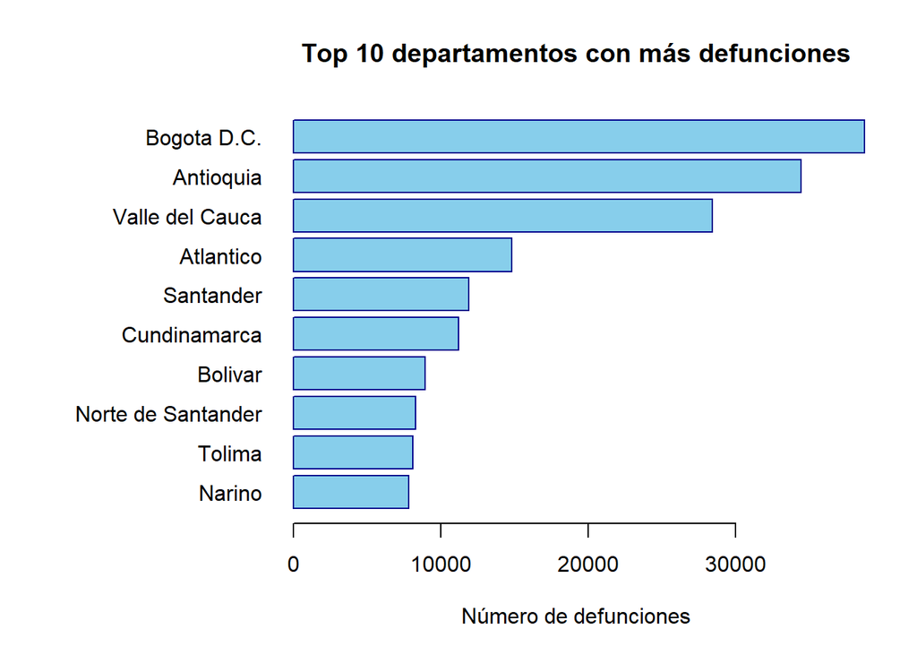

```r
par(mar = c(5, 11, 4, 2))
barplot(rev(top_dptos$Defunciones),
        names.arg = rev(top_dptos$Departamento),
        horiz = TRUE, las = 1,
        col = "skyblue", border = "darkblue",
        main = "Top 10 departamentos con más defunciones",
        xlab = "Número de defunciones")
```

### Top 10 municipios con más defunciones

```r
top_mpios <- data.frame(sort(table(data_limpia$Municipio), decreasing = TRUE))
colnames(top_mpios) <- c("Municipio", "Defunciones")
top_mpios$Porcentaje <- round(100 * top_mpios$Defunciones / nrow(data_limpia), 2)
top_mpios <- head(top_mpios, 10)
top_mpios
```

```
##       Municipio Defunciones Porcentaje
## 1   Bogota D.C.       38751      15.86
## 2      Medellin       19118       7.83
## 3          Cali       18045       7.39
## 4  Barranquilla       11074       4.53
## 5     Cartagena        6284       2.57
## 6        Cucuta        5698       2.33
## 7       Pereira        5093       2.08
## 8      Monteria        4812       1.97
## 9   Bucaramanga        4806       1.97
## 10       Ibague        4319       1.77
```

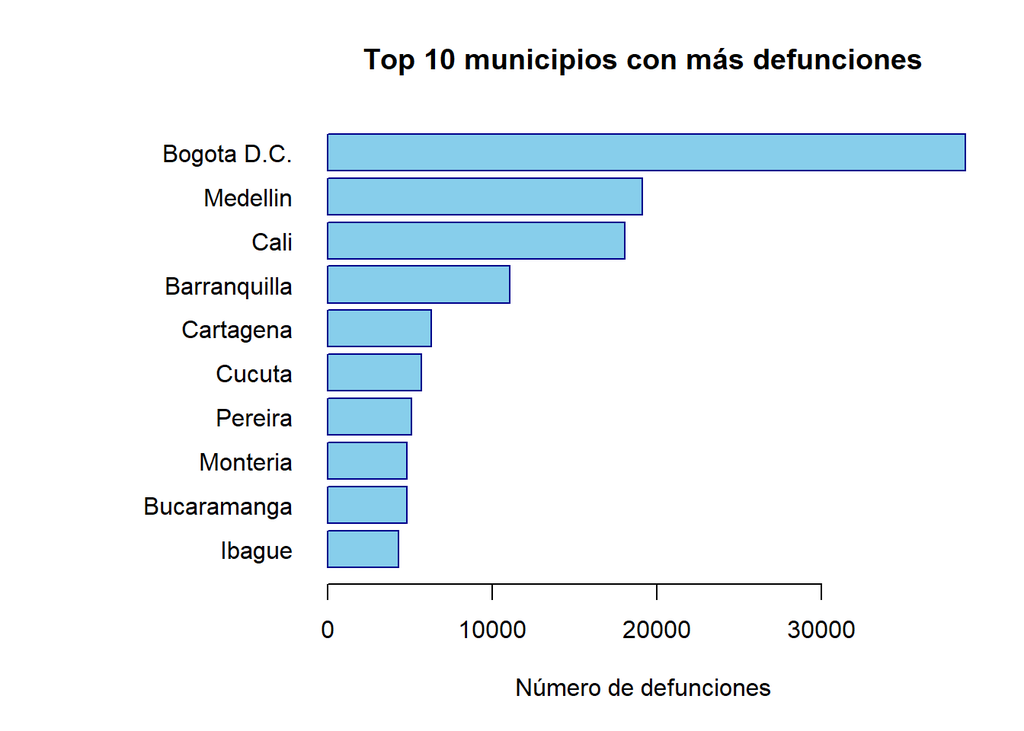

```r
par(mar = c(5, 11, 4, 2))
barplot(rev(top_mpios$Defunciones),
        names.arg = rev(top_mpios$Municipio),
        horiz = TRUE, las = 1,
        col = "skyblue", border = "darkblue",
        main = "Top 10 municipios con más defunciones",
        xlab = "Número de defunciones")
```

### Top 10 municipios con más homicidios

```r
homicidios <- data_limpia[data_limpia$Manera_Muerte == "Homicidio", ]

top_homicidios <- data.frame(sort(table(homicidios$Municipio), decreasing = TRUE))
colnames(top_homicidios) <- c("Municipio", "Homicidios")
top_homicidios <- head(top_homicidios, 10)
top_homicidios
```

```
##       Municipio Homicidios
## 1          Cali       1241
## 2   Bogota D.C.       1150
## 3      Medellin        638
## 4  Barranquilla        345
## 5        Cucuta        262
## 6     Cartagena        228
## 7        Tumaco        218
## 8       Pereira        147
## 9         Bello        141
## 10      Palmira        140
```

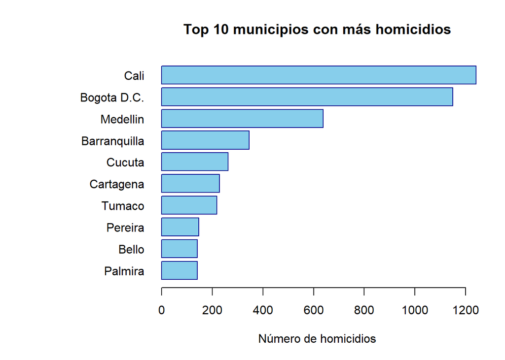

```r
par(mar = c(5, 11, 4, 2))
barplot(rev(top_homicidios$Homicidios),
        names.arg = rev(top_homicidios$Municipio),
        horiz = TRUE, las = 1,
        col = "skyblue", border = "darkblue",
        main = "Top 10 municipios con más homicidios",
        xlab = "Número de homicidios")
```